# Optimal Treatment Analysis

## Outcome Variable

**Outcome Variable:** ever_stunted

## Predictor Variables

**Intervention Variable:** earlybf

**Adjustment Set:**

- arm
- sex
- W_mage
- meducyrs
- feducyrs
- hhwealth_quart
- hfoodsec
- W_mhtcm
- vagbrth
- W_birthwt
- W_birthlen
- W_nrooms
- brthmon
- W_parity
- impfloor
- impsan
- safeh20
- delta_W_mage
- delta_meducyrs
- delta_feducyrs
- delta_hhwealth_quart
- delta_hfoodsec
- delta_W_mhtcm
- delta_vagbrth
- delta_W_birthwt
- delta_W_birthlen
- delta_W_nrooms
- delta_brthmon
- delta_W_parity
- delta_impfloor
- delta_impsan
- delta_safeh20

## Stratifying Variables

The analysis was stratified on these variable(s):

- agecat
- studyid
- country

## Data Summary

| agecat | studyid | country | earlybf | ever_stunted | n_cell | n |
| --- | --- | --- | --- | --- | --- | --- |
| 0-24 months (no birth st.) | ki0047075b-MAL-ED | BANGLADESH | 1 | 0 | 66 | 216 |
| 0-24 months (no birth st.) | ki0047075b-MAL-ED | BANGLADESH | 1 | 1 | 72 | 216 |
| 0-24 months (no birth st.) | ki0047075b-MAL-ED | BANGLADESH | 0 | 0 | 38 | 216 |
| 0-24 months (no birth st.) | ki0047075b-MAL-ED | BANGLADESH | 0 | 1 | 40 | 216 |
| 0-24 months (no birth st.) | ki0047075b-MAL-ED | BRAZIL | 1 | 0 | 83 | 208 |
| 0-24 months (no birth st.) | ki0047075b-MAL-ED | BRAZIL | 1 | 1 | 17 | 208 |
| 0-24 months (no birth st.) | ki0047075b-MAL-ED | BRAZIL | 0 | 0 | 96 | 208 |
| 0-24 months (no birth st.) | ki0047075b-MAL-ED | BRAZIL | 0 | 1 | 12 | 208 |
| 0-24 months (no birth st.) | ki0047075b-MAL-ED | INDIA | 1 | 0 | 61 | 208 |
| 0-24 months (no birth st.) | ki0047075b-MAL-ED | INDIA | 1 | 1 | 67 | 208 |
| 0-24 months (no birth st.) | ki0047075b-MAL-ED | INDIA | 0 | 0 | 39 | 208 |
| 0-24 months (no birth st.) | ki0047075b-MAL-ED | INDIA | 0 | 1 | 41 | 208 |
| 0-24 months (no birth st.) | ki0047075b-MAL-ED | NEPAL | 1 | 0 | 65 | 212 |
| 0-24 months (no birth st.) | ki0047075b-MAL-ED | NEPAL | 1 | 1 | 25 | 212 |
| 0-24 months (no birth st.) | ki0047075b-MAL-ED | NEPAL | 0 | 0 | 92 | 212 |
| 0-24 months (no birth st.) | ki0047075b-MAL-ED | NEPAL | 0 | 1 | 30 | 212 |
| 0-24 months (no birth st.) | ki0047075b-MAL-ED | PERU | 1 | 0 | 85 | 266 |
| 0-24 months (no birth st.) | ki0047075b-MAL-ED | PERU | 1 | 1 | 117 | 266 |
| 0-24 months (no birth st.) | ki0047075b-MAL-ED | PERU | 0 | 0 | 30 | 266 |
| 0-24 months (no birth st.) | ki0047075b-MAL-ED | PERU | 0 | 1 | 34 | 266 |
| 0-24 months (no birth st.) | ki0047075b-MAL-ED | SOUTH AFRICA | 1 | 0 | 81 | 265 |
| 0-24 months (no birth st.) | ki0047075b-MAL-ED | SOUTH AFRICA | 1 | 1 | 86 | 265 |
| 0-24 months (no birth st.) | ki0047075b-MAL-ED | SOUTH AFRICA | 0 | 0 | 51 | 265 |
| 0-24 months (no birth st.) | ki0047075b-MAL-ED | SOUTH AFRICA | 0 | 1 | 47 | 265 |
| 0-24 months (no birth st.) | ki0047075b-MAL-ED | TANZANIA, UNITED REPUBLIC OF | 1 | 0 | 33 | 219 |
| 0-24 months (no birth st.) | ki0047075b-MAL-ED | TANZANIA, UNITED REPUBLIC OF | 1 | 1 | 151 | 219 |
| 0-24 months (no birth st.) | ki0047075b-MAL-ED | TANZANIA, UNITED REPUBLIC OF | 0 | 0 | 8 | 219 |
| 0-24 months (no birth st.) | ki0047075b-MAL-ED | TANZANIA, UNITED REPUBLIC OF | 0 | 1 | 27 | 219 |
| 0-24 months (no birth st.) | ki1000109-EE | PAKISTAN | 1 | 0 | 10 | 249 |
| 0-24 months (no birth st.) | ki1000109-EE | PAKISTAN | 1 | 1 | 39 | 249 |

[output cut: 138 more lines]

The following strata were considered:

- agecat: 0-24 months (no birth st.), studyid: ki0047075b-MAL-ED, country: BANGLADESH
- agecat: 0-24 months (no birth st.), studyid: ki0047075b-MAL-ED, country: BRAZIL
- agecat: 0-24 months (no birth st.), studyid: ki0047075b-MAL-ED, country: INDIA
- agecat: 0-24 months (no birth st.), studyid: ki0047075b-MAL-ED, country: NEPAL
- agecat: 0-24 months (no birth st.), studyid: ki0047075b-MAL-ED, country: PERU
- agecat: 0-24 months (no birth st.), studyid: ki0047075b-MAL-ED, country: SOUTH AFRICA
- agecat: 0-24 months (no birth st.), studyid: ki0047075b-MAL-ED, country: TANZANIA, UNITED REPUBLIC OF
- agecat: 0-24 months (no birth st.), studyid: ki1000109-EE, country: PAKISTAN
- agecat: 0-24 months (no birth st.), studyid: ki1000304b-SAS-CompFeed, country: INDIA
- agecat: 0-24 months (no birth st.), studyid: ki1017093c-NIH-Crypto, country: BANGLADESH
- agecat: 0-24 months (no birth st.), studyid: ki1113344-GMS-Nepal, country: NEPAL
- agecat: 0-24 months (no birth st.), studyid: ki1126311-ZVITAMBO, country: ZIMBABWE
- agecat: 0-24 months (no birth st.), studyid: kiGH5241-JiVitA-3, country: BANGLADESH
- agecat: 0-24 months (no birth st.), studyid: kiGH5241-JiVitA-4, country: BANGLADESH
- agecat: 0-6 months (no birth st.), studyid: ki0047075b-MAL-ED, country: BANGLADESH
- agecat: 0-6 months (no birth st.), studyid: ki0047075b-MAL-ED, country: BRAZIL
- agecat: 0-6 months (no birth st.), studyid: ki0047075b-MAL-ED, country: INDIA
- agecat: 0-6 months (no birth st.), studyid: ki0047075b-MAL-ED, country: NEPAL
- agecat: 0-6 months (no birth st.), studyid: ki0047075b-MAL-ED, country: PERU
- agecat: 0-6 months (no birth st.), studyid: ki0047075b-MAL-ED, country: SOUTH AFRICA
- agecat: 0-6 months (no birth st.), studyid: ki0047075b-MAL-ED, country: TANZANIA, UNITED REPUBLIC OF
- agecat: 0-6 months (no birth st.), studyid: ki1000109-EE, country: PAKISTAN
- agecat: 0-6 months (no birth st.), studyid: ki1000304b-SAS-CompFeed, country: INDIA
- agecat: 0-6 months (no birth st.), studyid: ki1017093c-NIH-Crypto, country: BANGLADESH
- agecat: 0-6 months (no birth st.), studyid: ki1113344-GMS-Nepal, country: NEPAL
- agecat: 0-6 months (no birth st.), studyid: ki1126311-ZVITAMBO, country: ZIMBABWE
- agecat: 0-6 months (no birth st.), studyid: kiGH5241-JiVitA-3, country: BANGLADESH
- agecat: 0-6 months (no birth st.), studyid: kiGH5241-JiVitA-4, country: BANGLADESH
- agecat: 6-24 months, studyid: ki0047075b-MAL-ED, country: BANGLADESH
- agecat: 6-24 months, studyid: ki0047075b-MAL-ED, country: BRAZIL
- agecat: 6-24 months, studyid: ki0047075b-MAL-ED, country: INDIA
- agecat: 6-24 months, studyid: ki0047075b-MAL-ED, country: NEPAL
- agecat: 6-24 months, studyid: ki0047075b-MAL-ED, country: PERU
- agecat: 6-24 months, studyid: ki0047075b-MAL-ED, country: SOUTH AFRICA
- agecat: 6-24 months, studyid: ki0047075b-MAL-ED, country: TANZANIA, UNITED REPUBLIC OF
- agecat: 6-24 months, studyid: ki1000109-EE, country: PAKISTAN
- agecat: 6-24 months, studyid: ki1000304b-SAS-CompFeed, country: INDIA
- agecat: 6-24 months, studyid: ki1017093c-NIH-Crypto, country: BANGLADESH
- agecat: 6-24 months, studyid: ki1113344-GMS-Nepal, country: NEPAL
- agecat: 6-24 months, studyid: ki1126311-ZVITAMBO, country: ZIMBABWE
- agecat: 6-24 months, studyid: kiGH5241-JiVitA-3, country: BANGLADESH
- agecat: 6-24 months, studyid: kiGH5241-JiVitA-4, country: BANGLADESH

### Dropped Strata

Some strata were dropped due to rare outcomes:

- agecat: 6-24 months, studyid: ki0047075b-MAL-ED, country: BRAZIL
- agecat: 6-24 months, studyid: kiGH5241-JiVitA-3, country: BANGLADESH

## Methods Detail

We’re interested in the causal parameters $E[Y_a]$ for all values of $a \in \mathcal{A}$. These parameters represent the mean outcome if, possibly contrary to fact, we intervened to set all units to have $A=a$. Under the randomization and positivity assumptions, these are identified by the statistical parameters $\psi_a=E_W[E_{Y|A,W}(Y|A=a,W)]$. In addition, we’re interested in the mean of $Y$, $E[Y]$ under no intervention (the observed mean). We will estimate these parameters by using SuperLearner to fit the relevant likelihood factors – $E_{Y|A,W}(Y|A=a,W)$ and $p(A=a|W)$, and then updating our likelihood fit using a joint TMLE.

For unadjusted analyses ($W=\{\}$), initial likelihoods were estimated using Lrnr_glm to estimate the simple $E(Y|A)$ and Lrnr_mean to estimate $p(A)$. For adjusted analyses, a small library containing Lrnr_glmnet, Lrnr_xgboost, and Lrnr_mean was used.

Having estimated these parameters, we will then use the delta method to estimate relative risks and attributable risks relative to a prespecified baseline level of $A$.

# Results Detail

## Results Plots

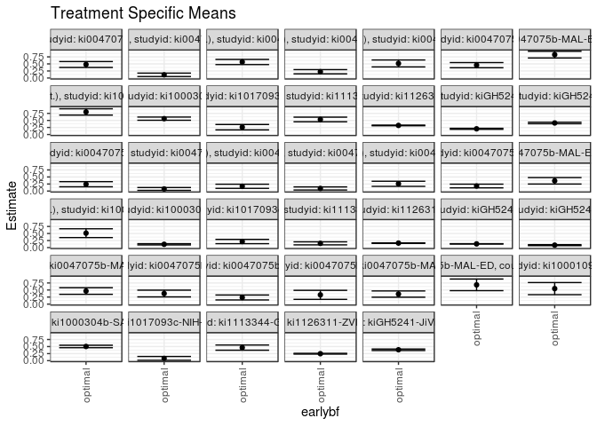

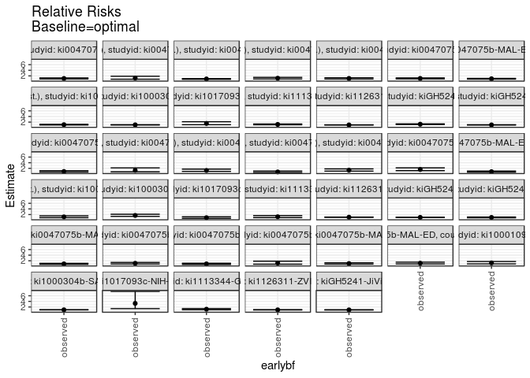

## Results Table

### Parameter: TSM

| agecat | studyid | country | intervention_level | baseline_level | estimate | ci_lower | ci_upper |
| --- | --- | --- | --- | --- | --- | --- | --- |
| 0-24 months (no birth st.) | ki0047075b-MAL-ED | BANGLADESH | optimal | NA | 0.4787874 | 0.3744471 | 0.5831276 |
| 0-24 months (no birth st.) | ki0047075b-MAL-ED | BRAZIL | optimal | NA | 0.1126592 | 0.0520077 | 0.1733108 |
| 0-24 months (no birth st.) | ki0047075b-MAL-ED | INDIA | optimal | NA | 0.5681579 | 0.4762161 | 0.6600998 |
| 0-24 months (no birth st.) | ki0047075b-MAL-ED | NEPAL | optimal | NA | 0.2223055 | 0.1474940 | 0.2971170 |
| 0-24 months (no birth st.) | ki0047075b-MAL-ED | PERU | optimal | NA | 0.5162406 | 0.3928912 | 0.6395901 |
| 0-24 months (no birth st.) | ki0047075b-MAL-ED | SOUTH AFRICA | optimal | NA | 0.4558546 | 0.3641517 | 0.5475575 |
| 0-24 months (no birth st.) | ki0047075b-MAL-ED | TANZANIA, UNITED REPUBLIC OF | optimal | NA | 0.8289249 | 0.7100601 | 0.9477898 |
| 0-24 months (no birth st.) | ki1000109-EE | PAKISTAN | optimal | NA | 0.8016884 | 0.6897707 | 0.9136060 |
| 0-24 months (no birth st.) | ki1000304b-SAS-CompFeed | INDIA | optimal | NA | 0.5628479 | 0.5058201 | 0.6198757 |
| 0-24 months (no birth st.) | ki1017093c-NIH-Crypto | BANGLADESH | optimal | NA | 0.2606813 | 0.1654166 | 0.3559459 |
| 0-24 months (no birth st.) | ki1113344-GMS-Nepal | NEPAL | optimal | NA | 0.5346081 | 0.4526847 | 0.6165315 |
| 0-24 months (no birth st.) | ki1126311-ZVITAMBO | ZIMBABWE | optimal | NA | 0.3231599 | 0.3113872 | 0.3349325 |
| 0-24 months (no birth st.) | kiGH5241-JiVitA-3 | BANGLADESH | optimal | NA | 0.2033530 | 0.1864254 | 0.2202806 |
| 0-24 months (no birth st.) | kiGH5241-JiVitA-4 | BANGLADESH | optimal | NA | 0.4098146 | 0.3830707 | 0.4365585 |
| 0-6 months (no birth st.) | ki0047075b-MAL-ED | BANGLADESH | optimal | NA | 0.2420743 | 0.1512233 | 0.3329252 |
| 0-6 months (no birth st.) | ki0047075b-MAL-ED | BRAZIL | optimal | NA | 0.0744870 | 0.0244910 | 0.1244831 |
| 0-6 months (no birth st.) | ki0047075b-MAL-ED | INDIA | optimal | NA | 0.1689519 | 0.0952600 | 0.2426438 |
| 0-6 months (no birth st.) | ki0047075b-MAL-ED | NEPAL | optimal | NA | 0.0923592 | 0.0371895 | 0.1475289 |
| 0-6 months (no birth st.) | ki0047075b-MAL-ED | PERU | optimal | NA | 0.2574971 | 0.1671460 | 0.3478483 |
| 0-6 months (no birth st.) | ki0047075b-MAL-ED | SOUTH AFRICA | optimal | NA | 0.1793572 | 0.1137608 | 0.2449536 |
| 0-6 months (no birth st.) | ki0047075b-MAL-ED | TANZANIA, UNITED REPUBLIC OF | optimal | NA | 0.3635180 | 0.2490132 | 0.4780229 |
| 0-6 months (no birth st.) | ki1000109-EE | PAKISTAN | optimal | NA | 0.5114414 | 0.3553873 | 0.6674956 |
| 0-6 months (no birth st.) | ki1000304b-SAS-CompFeed | INDIA | optimal | NA | 0.1171239 | 0.0956236 | 0.1386242 |
| 0-6 months (no birth st.) | ki1017093c-NIH-Crypto | BANGLADESH | optimal | NA | 0.2146807 | 0.1388804 | 0.2904811 |
| 0-6 months (no birth st.) | ki1113344-GMS-Nepal | NEPAL | optimal | NA | 0.1502309 | 0.0971163 | 0.2033455 |
| 0-6 months (no birth st.) | ki1126311-ZVITAMBO | ZIMBABWE | optimal | NA | 0.1594429 | 0.1503098 | 0.1685761 |
| 0-6 months (no birth st.) | kiGH5241-JiVitA-3 | BANGLADESH | optimal | NA | 0.1314720 | 0.1257381 | 0.1372059 |
| 0-6 months (no birth st.) | kiGH5241-JiVitA-4 | BANGLADESH | optimal | NA | 0.0872678 | 0.0702942 | 0.1042414 |
| 6-24 months | ki0047075b-MAL-ED | BANGLADESH | optimal | NA | 0.4639783 | 0.3467665 | 0.5811900 |
| 6-24 months | ki0047075b-MAL-ED | INDIA | optimal | NA | 0.3755351 | 0.2559676 | 0.4951026 |
| 6-24 months | ki0047075b-MAL-ED | NEPAL | optimal | NA | 0.2353653 | 0.1476181 | 0.3231126 |
| 6-24 months | ki0047075b-MAL-ED | PERU | optimal | NA | 0.3289893 | 0.1692017 | 0.4887770 |
| 6-24 months | ki0047075b-MAL-ED | SOUTH AFRICA | optimal | NA | 0.3558203 | 0.2451747 | 0.4664658 |
| 6-24 months | ki0047075b-MAL-ED | TANZANIA, UNITED REPUBLIC OF | optimal | NA | 0.6834621 | 0.4773173 | 0.8896069 |
| 6-24 months | ki1000109-EE | PAKISTAN | optimal | NA | 0.5499734 | 0.3352650 | 0.7646818 |
| 6-24 months | ki1000304b-SAS-CompFeed | INDIA | optimal | NA | 0.5028509 | 0.4590263 | 0.5466755 |
| 6-24 months | ki1017093c-NIH-Crypto | BANGLADESH | optimal | NA | 0.0801353 | 0.0117980 | 0.1484727 |
| 6-24 months | ki1113344-GMS-Nepal | NEPAL | optimal | NA | 0.4618724 | 0.3698831 | 0.5538616 |
| 6-24 months | ki1126311-ZVITAMBO | ZIMBABWE | optimal | NA | 0.2464436 | 0.2323591 | 0.2605281 |
| 6-24 months | kiGH5241-JiVitA-4 | BANGLADESH | optimal | NA | 0.3866459 | 0.3597021 | 0.4135897 |

### Parameter: E(Y)

| agecat | studyid | country | intervention_level | baseline_level | estimate | ci_lower | ci_upper |
| --- | --- | --- | --- | --- | --- | --- | --- |
| 0-24 months (no birth st.) | ki0047075b-MAL-ED | BANGLADESH | observed | NA | 0.5185185 | 0.4517302 | 0.5853069 |
| 0-24 months (no birth st.) | ki0047075b-MAL-ED | BRAZIL | observed | NA | 0.1394231 | 0.0922358 | 0.1866104 |
| 0-24 months (no birth st.) | ki0047075b-MAL-ED | INDIA | observed | NA | 0.5192308 | 0.4511677 | 0.5872938 |
| 0-24 months (no birth st.) | ki0047075b-MAL-ED | NEPAL | observed | NA | 0.2594340 | 0.2002911 | 0.3185768 |
| 0-24 months (no birth st.) | ki0047075b-MAL-ED | PERU | observed | NA | 0.5676692 | 0.5080232 | 0.6273151 |
| 0-24 months (no birth st.) | ki0047075b-MAL-ED | SOUTH AFRICA | observed | NA | 0.5018868 | 0.4415735 | 0.5622001 |
| 0-24 months (no birth st.) | ki0047075b-MAL-ED | TANZANIA, UNITED REPUBLIC OF | observed | NA | 0.8127854 | 0.7610035 | 0.8645672 |
| 0-24 months (no birth st.) | ki1000109-EE | PAKISTAN | observed | NA | 0.8674699 | 0.8252704 | 0.9096693 |
| 0-24 months (no birth st.) | ki1000304b-SAS-CompFeed | INDIA | observed | NA | 0.5804327 | 0.5278252 | 0.6330403 |
| 0-24 months (no birth st.) | ki1017093c-NIH-Crypto | BANGLADESH | observed | NA | 0.3935681 | 0.3560687 | 0.4310676 |
| 0-24 months (no birth st.) | ki1113344-GMS-Nepal | NEPAL | observed | NA | 0.6280488 | 0.5852977 | 0.6707999 |
| 0-24 months (no birth st.) | ki1126311-ZVITAMBO | ZIMBABWE | observed | NA | 0.3237628 | 0.3151026 | 0.3324231 |
| 0-24 months (no birth st.) | kiGH5241-JiVitA-3 | BANGLADESH | observed | NA | 0.2544842 | 0.2466711 | 0.2622973 |
| 0-24 months (no birth st.) | kiGH5241-JiVitA-4 | BANGLADESH | observed | NA | 0.4135358 | 0.3953404 | 0.4317312 |
| 0-6 months (no birth st.) | ki0047075b-MAL-ED | BANGLADESH | observed | NA | 0.2129630 | 0.1582389 | 0.2676870 |
| 0-6 months (no birth st.) | ki0047075b-MAL-ED | BRAZIL | observed | NA | 0.0961538 | 0.0559939 | 0.1363138 |
| 0-6 months (no birth st.) | ki0047075b-MAL-ED | INDIA | observed | NA | 0.2115385 | 0.1559035 | 0.2671734 |
| 0-6 months (no birth st.) | ki0047075b-MAL-ED | NEPAL | observed | NA | 0.0660377 | 0.0325283 | 0.0995472 |
| 0-6 months (no birth st.) | ki0047075b-MAL-ED | PERU | observed | NA | 0.3458647 | 0.2885967 | 0.4031327 |
| 0-6 months (no birth st.) | ki0047075b-MAL-ED | SOUTH AFRICA | observed | NA | 0.2867925 | 0.2322370 | 0.3413479 |
| 0-6 months (no birth st.) | ki0047075b-MAL-ED | TANZANIA, UNITED REPUBLIC OF | observed | NA | 0.2968037 | 0.2361590 | 0.3574483 |
| 0-6 months (no birth st.) | ki1000109-EE | PAKISTAN | observed | NA | 0.6024096 | 0.5415000 | 0.6633193 |
| 0-6 months (no birth st.) | ki1000304b-SAS-CompFeed | INDIA | observed | NA | 0.1977401 | 0.1736271 | 0.2218531 |
| 0-6 months (no birth st.) | ki1017093c-NIH-Crypto | BANGLADESH | observed | NA | 0.1898928 | 0.1597870 | 0.2199986 |
| 0-6 months (no birth st.) | ki1113344-GMS-Nepal | NEPAL | observed | NA | 0.1829268 | 0.1487307 | 0.2171229 |
| 0-6 months (no birth st.) | ki1126311-ZVITAMBO | ZIMBABWE | observed | NA | 0.1700741 | 0.1631162 | 0.1770320 |
| 0-6 months (no birth st.) | kiGH5241-JiVitA-3 | BANGLADESH | observed | NA | 0.1316263 | 0.1259812 | 0.1372713 |
| 0-6 months (no birth st.) | kiGH5241-JiVitA-4 | BANGLADESH | observed | NA | 0.0855425 | 0.0741829 | 0.0969021 |
| 6-24 months | ki0047075b-MAL-ED | BANGLADESH | observed | NA | 0.4177215 | 0.3405766 | 0.4948664 |
| 6-24 months | ki0047075b-MAL-ED | INDIA | observed | NA | 0.4129032 | 0.3351414 | 0.4906651 |
| 6-24 months | ki0047075b-MAL-ED | NEPAL | observed | NA | 0.2102564 | 0.1529155 | 0.2675974 |
| 6-24 months | ki0047075b-MAL-ED | PERU | observed | NA | 0.3959732 | 0.3171819 | 0.4747644 |
| 6-24 months | ki0047075b-MAL-ED | SOUTH AFRICA | observed | NA | 0.3630573 | 0.2875961 | 0.4385185 |
| 6-24 months | ki0047075b-MAL-ED | TANZANIA, UNITED REPUBLIC OF | observed | NA | 0.7793103 | 0.7115754 | 0.8470453 |
| 6-24 months | ki1000109-EE | PAKISTAN | observed | NA | 0.6804124 | 0.5871313 | 0.7736934 |
| 6-24 months | ki1000304b-SAS-CompFeed | INDIA | observed | NA | 0.5030750 | 0.4588491 | 0.5473009 |
| 6-24 months | ki1017093c-NIH-Crypto | BANGLADESH | observed | NA | 0.2628458 | 0.2244546 | 0.3012371 |
| 6-24 months | ki1113344-GMS-Nepal | NEPAL | observed | NA | 0.5572519 | 0.5080809 | 0.6064229 |
| 6-24 months | ki1126311-ZVITAMBO | ZIMBABWE | observed | NA | 0.2447019 | 0.2346857 | 0.2547181 |
| 6-24 months | kiGH5241-JiVitA-4 | BANGLADESH | observed | NA | 0.3779118 | 0.3593176 | 0.3965059 |

### Parameter: RR

| agecat | studyid | country | intervention_level | baseline_level | estimate | ci_lower | ci_upper |
| --- | --- | --- | --- | --- | --- | --- | --- |
| 0-24 months (no birth st.) | ki0047075b-MAL-ED | BANGLADESH | observed | optimal | 1.0829829 | 0.9138402 | 1.283432 |
| 0-24 months (no birth st.) | ki0047075b-MAL-ED | BRAZIL | observed | optimal | 1.2375647 | 0.8221871 | 1.862796 |
| 0-24 months (no birth st.) | ki0047075b-MAL-ED | INDIA | observed | optimal | 0.9138846 | 0.8122332 | 1.028258 |
| 0-24 months (no birth st.) | ki0047075b-MAL-ED | NEPAL | observed | optimal | 1.1670156 | 0.9212769 | 1.478302 |
| 0-24 months (no birth st.) | ki0047075b-MAL-ED | PERU | observed | optimal | 1.0996212 | 0.8942679 | 1.352130 |
| 0-24 months (no birth st.) | ki0047075b-MAL-ED | SOUTH AFRICA | observed | optimal | 1.1009800 | 0.9463412 | 1.280888 |
| 0-24 months (no birth st.) | ki0047075b-MAL-ED | TANZANIA, UNITED REPUBLIC OF | observed | optimal | 0.9805295 | 0.8600733 | 1.117856 |
| 0-24 months (no birth st.) | ki1000109-EE | PAKISTAN | observed | optimal | 1.0820537 | 0.9583040 | 1.221784 |
| 0-24 months (no birth st.) | ki1000304b-SAS-CompFeed | INDIA | observed | optimal | 1.0312426 | 0.9727741 | 1.093225 |
| 0-24 months (no birth st.) | ki1017093c-NIH-Crypto | BANGLADESH | observed | optimal | 1.5097676 | 1.0685773 | 2.133115 |
| 0-24 months (no birth st.) | ki1113344-GMS-Nepal | NEPAL | observed | optimal | 1.1747836 | 1.0336242 | 1.335221 |
| 0-24 months (no birth st.) | ki1126311-ZVITAMBO | ZIMBABWE | observed | optimal | 1.0018658 | 0.9772025 | 1.027152 |
| 0-24 months (no birth st.) | kiGH5241-JiVitA-3 | BANGLADESH | observed | optimal | 1.2514404 | 1.1485630 | 1.363533 |
| 0-24 months (no birth st.) | kiGH5241-JiVitA-4 | BANGLADESH | observed | optimal | 1.0090802 | 0.9598172 | 1.060872 |
| 0-6 months (no birth st.) | ki0047075b-MAL-ED | BANGLADESH | observed | optimal | 0.8797423 | 0.6656566 | 1.162681 |
| 0-6 months (no birth st.) | ki0047075b-MAL-ED | BRAZIL | observed | optimal | 1.2908802 | 0.7701546 | 2.163685 |
| 0-6 months (no birth st.) | ki0047075b-MAL-ED | INDIA | observed | optimal | 1.2520631 | 0.9071809 | 1.728059 |
| 0-6 months (no birth st.) | ki0047075b-MAL-ED | NEPAL | observed | optimal | 0.7150100 | 0.4925001 | 1.038049 |
| 0-6 months (no birth st.) | ki0047075b-MAL-ED | PERU | observed | optimal | 1.3431787 | 1.0018262 | 1.800840 |
| 0-6 months (no birth st.) | ki0047075b-MAL-ED | SOUTH AFRICA | observed | optimal | 1.5990017 | 1.1775169 | 2.171355 |
| 0-6 months (no birth st.) | ki0047075b-MAL-ED | TANZANIA, UNITED REPUBLIC OF | observed | optimal | 0.8164758 | 0.6376964 | 1.045376 |
| 0-6 months (no birth st.) | ki1000109-EE | PAKISTAN | observed | optimal | 1.1778663 | 0.8914657 | 1.556279 |
| 0-6 months (no birth st.) | ki1000304b-SAS-CompFeed | INDIA | observed | optimal | 1.6882989 | 1.3527754 | 2.107041 |
| 0-6 months (no birth st.) | ki1017093c-NIH-Crypto | BANGLADESH | observed | optimal | 0.8845359 | 0.6411582 | 1.220297 |
| 0-6 months (no birth st.) | ki1113344-GMS-Nepal | NEPAL | observed | optimal | 1.2176378 | 0.9100122 | 1.629255 |
| 0-6 months (no birth st.) | ki1126311-ZVITAMBO | ZIMBABWE | observed | optimal | 1.0666769 | 1.0249937 | 1.110055 |
| 0-6 months (no birth st.) | kiGH5241-JiVitA-3 | BANGLADESH | observed | optimal | 1.0011731 | 0.9905163 | 1.011945 |
| 0-6 months (no birth st.) | kiGH5241-JiVitA-4 | BANGLADESH | observed | optimal | 0.9802296 | 0.8514171 | 1.128531 |
| 6-24 months | ki0047075b-MAL-ED | BANGLADESH | observed | optimal | 0.9003040 | 0.7380247 | 1.098266 |
| 6-24 months | ki0047075b-MAL-ED | INDIA | observed | optimal | 1.0995063 | 0.8544057 | 1.414918 |
| 6-24 months | ki0047075b-MAL-ED | NEPAL | observed | optimal | 0.8933194 | 0.7106997 | 1.122864 |
| 6-24 months | ki0047075b-MAL-ED | PERU | observed | optimal | 1.2036049 | 0.7835894 | 1.848755 |
| 6-24 months | ki0047075b-MAL-ED | SOUTH AFRICA | observed | optimal | 1.0203391 | 0.8112609 | 1.283301 |
| 6-24 months | ki0047075b-MAL-ED | TANZANIA, UNITED REPUBLIC OF | observed | optimal | 1.1402393 | 0.8659545 | 1.501402 |
| 6-24 months | ki1000109-EE | PAKISTAN | observed | optimal | 1.2371733 | 0.8833079 | 1.732802 |
| 6-24 months | ki1000304b-SAS-CompFeed | INDIA | observed | optimal | 1.0004457 | 0.9718111 | 1.029924 |
| 6-24 months | ki1017093c-NIH-Crypto | BANGLADESH | observed | optimal | 3.2800242 | 1.4253720 | 7.547895 |
| 6-24 months | ki1113344-GMS-Nepal | NEPAL | observed | optimal | 1.2065063 | 1.0196856 | 1.427555 |
| 6-24 months | ki1126311-ZVITAMBO | ZIMBABWE | observed | optimal | 0.9929327 | 0.9534391 | 1.034062 |
| 6-24 months | kiGH5241-JiVitA-4 | BANGLADESH | observed | optimal | 0.9774105 | 0.9281659 | 1.029268 |

### Parameter: PAR

| agecat | studyid | country | intervention_level | baseline_level | estimate | ci_lower | ci_upper |
| --- | --- | --- | --- | --- | --- | --- | --- |
| 0-24 months (no birth st.) | ki0047075b-MAL-ED | BANGLADESH | optimal | NA | 0.0397312 | -0.0414957 | 0.1209580 |
| 0-24 months (no birth st.) | ki0047075b-MAL-ED | BRAZIL | optimal | NA | 0.0267639 | -0.0199287 | 0.0734564 |
| 0-24 months (no birth st.) | ki0047075b-MAL-ED | INDIA | optimal | NA | -0.0489272 | -0.1152091 | 0.0173547 |
| 0-24 months (no birth st.) | ki0047075b-MAL-ED | NEPAL | optimal | NA | 0.0371285 | -0.0156933 | 0.0899503 |
| 0-24 months (no birth st.) | ki0047075b-MAL-ED | PERU | optimal | NA | 0.0514285 | -0.0550100 | 0.1578670 |
| 0-24 months (no birth st.) | ki0047075b-MAL-ED | SOUTH AFRICA | optimal | NA | 0.0460322 | -0.0227097 | 0.1147741 |
| 0-24 months (no birth st.) | ki0047075b-MAL-ED | TANZANIA, UNITED REPUBLIC OF | optimal | NA | -0.0161395 | -0.1247542 | 0.0924751 |
| 0-24 months (no birth st.) | ki1000109-EE | PAKISTAN | optimal | NA | 0.0657815 | -0.0309928 | 0.1625558 |
| 0-24 months (no birth st.) | ki1000304b-SAS-CompFeed | INDIA | optimal | NA | 0.0175848 | -0.0155094 | 0.0506791 |
| 0-24 months (no birth st.) | ki1017093c-NIH-Crypto | BANGLADESH | optimal | NA | 0.1328869 | 0.0428623 | 0.2229114 |
| 0-24 months (no birth st.) | ki1113344-GMS-Nepal | NEPAL | optimal | NA | 0.0934407 | 0.0256097 | 0.1612717 |
| 0-24 months (no birth st.) | ki1126311-ZVITAMBO | ZIMBABWE | optimal | NA | 0.0006030 | -0.0074521 | 0.0086580 |
| 0-24 months (no birth st.) | kiGH5241-JiVitA-3 | BANGLADESH | optimal | NA | 0.0511312 | 0.0332137 | 0.0690487 |
| 0-24 months (no birth st.) | kiGH5241-JiVitA-4 | BANGLADESH | optimal | NA | 0.0037212 | -0.0167981 | 0.0242405 |
| 0-6 months (no birth st.) | ki0047075b-MAL-ED | BANGLADESH | optimal | NA | -0.0291113 | -0.0968755 | 0.0386529 |
| 0-6 months (no birth st.) | ki0047075b-MAL-ED | BRAZIL | optimal | NA | 0.0216668 | -0.0176643 | 0.0609979 |
| 0-6 months (no birth st.) | ki0047075b-MAL-ED | INDIA | optimal | NA | 0.0425865 | -0.0118625 | 0.0970356 |
| 0-6 months (no birth st.) | ki0047075b-MAL-ED | NEPAL | optimal | NA | -0.0263214 | -0.0619239 | 0.0092810 |
| 0-6 months (no birth st.) | ki0047075b-MAL-ED | PERU | optimal | NA | 0.0883675 | 0.0129137 | 0.1638214 |
| 0-6 months (no birth st.) | ki0047075b-MAL-ED | SOUTH AFRICA | optimal | NA | 0.1074353 | 0.0495294 | 0.1653412 |
| 0-6 months (no birth st.) | ki0047075b-MAL-ED | TANZANIA, UNITED REPUBLIC OF | optimal | NA | -0.0667144 | -0.1570982 | 0.0236695 |
| 0-6 months (no birth st.) | ki1000109-EE | PAKISTAN | optimal | NA | 0.0909682 | -0.0509520 | 0.2328884 |
| 0-6 months (no birth st.) | ki1000304b-SAS-CompFeed | INDIA | optimal | NA | 0.0806162 | 0.0481231 | 0.1131094 |
| 0-6 months (no birth st.) | ki1017093c-NIH-Crypto | BANGLADESH | optimal | NA | -0.0247879 | -0.0938265 | 0.0442507 |
| 0-6 months (no birth st.) | ki1113344-GMS-Nepal | NEPAL | optimal | NA | 0.0326959 | -0.0111848 | 0.0765767 |
| 0-6 months (no birth st.) | ki1126311-ZVITAMBO | ZIMBABWE | optimal | NA | 0.0106312 | 0.0042631 | 0.0169992 |
| 0-6 months (no birth st.) | kiGH5241-JiVitA-3 | BANGLADESH | optimal | NA | 0.0001542 | -0.0012531 | 0.0015616 |
| 0-6 months (no birth st.) | kiGH5241-JiVitA-4 | BANGLADESH | optimal | NA | -0.0017253 | -0.0140243 | 0.0105737 |
| 6-24 months | ki0047075b-MAL-ED | BANGLADESH | optimal | NA | -0.0462568 | -0.1377281 | 0.0452145 |
| 6-24 months | ki0047075b-MAL-ED | INDIA | optimal | NA | 0.0373681 | -0.0574371 | 0.1321733 |
| 6-24 months | ki0047075b-MAL-ED | NEPAL | optimal | NA | -0.0251089 | -0.0800358 | 0.0298180 |
| 6-24 months | ki0047075b-MAL-ED | PERU | optimal | NA | 0.0669838 | -0.0739001 | 0.2078678 |
| 6-24 months | ki0047075b-MAL-ED | SOUTH AFRICA | optimal | NA | 0.0072371 | -0.0743522 | 0.0888263 |
| 6-24 months | ki0047075b-MAL-ED | TANZANIA, UNITED REPUBLIC OF | optimal | NA | 0.0958483 | -0.0910528 | 0.2827493 |
| 6-24 months | ki1000109-EE | PAKISTAN | optimal | NA | 0.1304390 | -0.0517983 | 0.3126763 |
| 6-24 months | ki1000304b-SAS-CompFeed | INDIA | optimal | NA | 0.0002241 | -0.0143821 | 0.0148304 |
| 6-24 months | ki1017093c-NIH-Crypto | BANGLADESH | optimal | NA | 0.1827105 | 0.1119500 | 0.2534711 |
| 6-24 months | ki1113344-GMS-Nepal | NEPAL | optimal | NA | 0.0953795 | 0.0182372 | 0.1725218 |
| 6-24 months | ki1126311-ZVITAMBO | ZIMBABWE | optimal | NA | -0.0017417 | -0.0117432 | 0.0082598 |
| 6-24 months | kiGH5241-JiVitA-4 | BANGLADESH | optimal | NA | -0.0087341 | -0.0287069 | 0.0112386 |

### Parameter: PAF

| agecat | studyid | country | intervention_level | baseline_level | estimate | ci_lower | ci_upper |
| --- | --- | --- | --- | --- | --- | --- | --- |
| 0-24 months (no birth st.) | ki0047075b-MAL-ED | BANGLADESH | optimal | NA | 0.0766244 | -0.0942832 | 0.2208393 |
| 0-24 months (no birth st.) | ki0047075b-MAL-ED | BRAZIL | optimal | NA | 0.1919614 | -0.2162682 | 0.4631724 |
| 0-24 months (no birth st.) | ki0047075b-MAL-ED | INDIA | optimal | NA | -0.0942301 | -0.2311735 | 0.0274811 |
| 0-24 months (no birth st.) | ki0047075b-MAL-ED | NEPAL | optimal | NA | 0.1431134 | -0.0854500 | 0.3235482 |
| 0-24 months (no birth st.) | ki0047075b-MAL-ED | PERU | optimal | NA | 0.0905959 | -0.1182332 | 0.2604264 |
| 0-24 months (no birth st.) | ki0047075b-MAL-ED | SOUTH AFRICA | optimal | NA | 0.0917183 | -0.0567014 | 0.2192915 |
| 0-24 months (no birth st.) | ki0047075b-MAL-ED | TANZANIA, UNITED REPUBLIC OF | optimal | NA | -0.0198571 | -0.1626916 | 0.1054305 |
| 0-24 months (no birth st.) | ki1000109-EE | PAKISTAN | optimal | NA | 0.0758315 | -0.0435102 | 0.1815245 |
| 0-24 months (no birth st.) | ki1000304b-SAS-CompFeed | INDIA | optimal | NA | 0.0302961 | -0.0279879 | 0.0852756 |
| 0-24 months (no birth st.) | ki1017093c-NIH-Crypto | BANGLADESH | optimal | NA | 0.3376464 | 0.0641763 | 0.5312020 |
| 0-24 months (no birth st.) | ki1113344-GMS-Nepal | NEPAL | optimal | NA | 0.1487794 | 0.0325304 | 0.2510602 |
| 0-24 months (no birth st.) | ki1126311-ZVITAMBO | ZIMBABWE | optimal | NA | 0.0018624 | -0.0233293 | 0.0264339 |
| 0-24 months (no birth st.) | kiGH5241-JiVitA-3 | BANGLADESH | optimal | NA | 0.2009208 | 0.1293468 | 0.2666108 |
| 0-24 months (no birth st.) | kiGH5241-JiVitA-4 | BANGLADESH | optimal | NA | 0.0089985 | -0.0418650 | 0.0573788 |
| 0-6 months (no birth st.) | ki0047075b-MAL-ED | BANGLADESH | optimal | NA | -0.1366965 | -0.5022761 | 0.1399191 |
| 0-6 months (no birth st.) | ki0047075b-MAL-ED | BRAZIL | optimal | NA | 0.2253348 | -0.2984406 | 0.5378255 |
| 0-6 months (no birth st.) | ki0047075b-MAL-ED | INDIA | optimal | NA | 0.2013182 | -0.1023160 | 0.4213161 |
| 0-6 months (no birth st.) | ki0047075b-MAL-ED | NEPAL | optimal | NA | -0.3985819 | -1.0304565 | 0.0366543 |
| 0-6 months (no birth st.) | ki0047075b-MAL-ED | PERU | optimal | NA | 0.2554974 | 0.0018229 | 0.4447037 |
| 0-6 months (no birth st.) | ki0047075b-MAL-ED | SOUTH AFRICA | optimal | NA | 0.3746098 | 0.1507553 | 0.5394580 |
| 0-6 months (no birth st.) | ki0047075b-MAL-ED | TANZANIA, UNITED REPUBLIC OF | optimal | NA | -0.2247761 | -0.5681443 | 0.0434067 |
| 0-6 months (no birth st.) | ki1000109-EE | PAKISTAN | optimal | NA | 0.1510072 | -0.1217482 | 0.3574416 |
| 0-6 months (no birth st.) | ki1000304b-SAS-CompFeed | INDIA | optimal | NA | 0.4076878 | 0.2607790 | 0.5254008 |
| 0-6 months (no birth st.) | ki1017093c-NIH-Crypto | BANGLADESH | optimal | NA | -0.1305364 | -0.5596774 | 0.1805276 |
| 0-6 months (no birth st.) | ki1113344-GMS-Nepal | NEPAL | optimal | NA | 0.1787377 | -0.0988864 | 0.3862225 |
| 0-6 months (no birth st.) | ki1126311-ZVITAMBO | ZIMBABWE | optimal | NA | 0.0625090 | 0.0243843 | 0.0991438 |
| 0-6 months (no birth st.) | kiGH5241-JiVitA-3 | BANGLADESH | optimal | NA | 0.0011718 | -0.0095745 | 0.0118037 |
| 0-6 months (no birth st.) | kiGH5241-JiVitA-4 | BANGLADESH | optimal | NA | -0.0201691 | -0.1745125 | 0.1138919 |
| 6-24 months | ki0047075b-MAL-ED | BANGLADESH | optimal | NA | -0.1107359 | -0.3549681 | 0.0894736 |
| 6-24 months | ki0047075b-MAL-ED | INDIA | optimal | NA | 0.0905009 | -0.1704042 | 0.2932453 |
| 6-24 months | ki0047075b-MAL-ED | NEPAL | optimal | NA | -0.1194205 | -0.4070640 | 0.1094206 |
| 6-24 months | ki0047075b-MAL-ED | PERU | optimal | NA | 0.1691625 | -0.2761786 | 0.4590954 |
| 6-24 months | ki0047075b-MAL-ED | SOUTH AFRICA | optimal | NA | 0.0199337 | -0.2326491 | 0.2207596 |
| 6-24 months | ki0047075b-MAL-ED | TANZANIA, UNITED REPUBLIC OF | optimal | NA | 0.1229911 | -0.1547951 | 0.3339558 |
| 6-24 months | ki1000109-EE | PAKISTAN | optimal | NA | 0.1917058 | -0.1321080 | 0.4229000 |
| 6-24 months | ki1000304b-SAS-CompFeed | INDIA | optimal | NA | 0.0004455 | -0.0290065 | 0.0290545 |
| 6-24 months | ki1017093c-NIH-Crypto | BANGLADESH | optimal | NA | 0.6951242 | 0.2984288 | 0.8675127 |
| 6-24 months | ki1113344-GMS-Nepal | NEPAL | optimal | NA | 0.1711605 | 0.0193055 | 0.2995017 |
| 6-24 months | ki1126311-ZVITAMBO | ZIMBABWE | optimal | NA | -0.0071176 | -0.0488347 | 0.0329401 |
| 6-24 months | kiGH5241-JiVitA-4 | BANGLADESH | optimal | NA | -0.0231116 | -0.0773936 | 0.0284356 |